# Included Variable Bias in Ballard-Rosa, Mosley & Wellhausen (2022, IO): An Empirical Application

2026-02-27

# Introduction

Ballard-Rosa, Mosley, and Wellhausen (2022, *International Organization*) estimate the effect of government partisanship on the proportion of sovereign bonds issued in domestic currency. The main specification (Table 2, Column 3) is a country fixed effects model estimated on non-OECD countries at monthly frequency:

$$\text{propDom}_{it} = \beta_R \, \text{Right}_{i,t-1} + \beta_L \,
\text{Left}_{i,t-1} + \mathbf{Z}'_{it}\gamma + f(t) + \alpha_i +
\varepsilon_{it}$$

where $\text{propDom}_{it}$ is the proportion of sovereign bonds with maturity greater than 1 year issued in domestic currency (0–1), $\text{Right}_{i,t-1}$ and $\text{Left}_{i,t-1}$ are lagged partisan dummies (with centrist/other as the base category), $\mathbf{Z}_{it}$ is a vector of 16 controls (most lagged 12 months), $f(t)$ is a cubic time polynomial, and $\alpha_i$ are country fixed effects. Standard errors are clustered by country.

The paper’s key finding is that left-wing governments issue significantly more domestic-currency debt ($\hat\beta_L = 0.109$, $p < 0.05$), while right-wing governments issue less ($\hat\beta_R = -0.075$, $p < 0.05$).

A key question is whether any of these controls are **colliders** — variables caused by both the treatment (partisanship) and the outcome (bond denomination choice). If so, conditioning on them introduces **Included Variable Bias** (IVB). The IVB for each candidate collider $z_j$ is given by:

where $\hat\theta_j$ is the coefficient of $z_j$ in the “long” model (with all controls), and $\hat\pi_j$ is the coefficient of $\text{Left}_{i,t-1}$ in the auxiliary regression of $z_j$ on the treatment dummies and remaining controls.

Since the model includes **two treatment variables** (Right and Left, with Center as base), the IVB decomposition applies separately to each treatment coefficient. We focus on $\hat\beta_L$ (the Left coefficient) as it represents the paper’s main finding.

# Data

```r
dat <- read.delim(
  "Coming_to_Terms_data.tab",
  stringsAsFactors = FALSE
)
cat("Raw data:", nrow(dat), "rows,", ncol(dat), "columns\n")
```

```
## Raw data: 42768 rows, 64 columns
```

```r
cat("Countries:", length(unique(dat$ccode)), "\n")
```

```
## Countries: 132
```

```r
cat("Non-OECD countries:", length(unique(dat$ccode[dat$oecd == 0])), "\n")
```

```
## Non-OECD countries: 110
```

## Variable preparation

The Stata specification uses `l12.` (12-month lag) for most controls and `l.` (1-month lag) for the treatment. We create these lags in R by sorting within country-time panels. The data variables `oil_rents_gdp` and `fdi_net_inflow_gdp` correspond to the Stata do-file’s `oil_rents` and `fdi_net_inflow` respectively.

```r
dat <- dat %>%
  arrange(ccode, time) %>%
  group_by(ccode) %>%
  mutate(
    # Treatment: 1-month lag of partisan dummies
    l1_rightwing = lag(rightwing_exec_mo, 1),
    l1_leftwing  = lag(leftwing_exec_mo, 1),
    # Controls: 12-month lags
    l12_lngdppc       = lag(lngdppc, 12),
    l12_gdp_growth    = lag(gdp_growth, 12),
    l12_avgDebt_gdp   = lag(avgDebt_gdp, 12),
    l12_curr_act_gdp  = lag(curr_act_gdp, 12),
    l12_tradeGDP      = lag(tradeGDP, 12),
    l12_oil_rents     = lag(oil_rents_gdp, 12),
    l12_fdi_net       = lag(fdi_net_inflow_gdp, 12),
    l12_treasury10yr  = lag(treasury10yr, 12),
    l12_peg           = lag(peg, 12),
    l12_highCBI       = lag(highCBI, 12),
    l12_kaopen        = lag(kaopen, 12),
    l12_imfAnyInPlace = lag(imfAnyInPlace, 12),
    l12_v2x_polyarchy = lag(v2x_polyarchy, 12)
  ) %>%
  ungroup()

# Crisis variables are NOT lagged (contemporaneous)
# They already exist as: crisis_currency, crisis_inflation, crisis_sovdebt

# Filter to non-OECD
dat_nooecd <- dat %>% filter(oecd == 0)
cat("Non-OECD observations:", nrow(dat_nooecd), "\n")
```

```
## Non-OECD observations: 35640
```

# Specification

The Stata command for Table 2, Column 3 is:

```
xtreg propDom_gt1yr l.ib2.execrlc_mo l12.lngdppc l12.gdp_growth
  l12.avgDebt_gdp l12.curr_act_gdp l12.tradeGDP l12.oil_rents
  l12.fdi_net_inflow l12.treasury10yr l12.peg l12.highCBI l12.kaopen
  l12.imfAnyInPlace crisis_currency crisis_inflation crisis_sovdebt
  l12.v2x_polyarchy time time2 time3
  if oecd == 0, fe vce(cluster ccode)
```

The variables are:

| Role | Variable | Description |
| --- | --- | --- |
| $Y$ | `propDom_gt1yr` | Proportion of bonds > 1yr maturity issued in domestic currency |
| $D_R$ | `l.rightwing_exec_mo` | Right government (1-month lag) |
| $D_L$ | `l.leftwing_exec_mo` | Left government (1-month lag) |
| $Z_1$ | `l12.lngdppc` | Log GDP per capita (12-month lag) |
| $Z_2$ | `l12.gdp_growth` | GDP growth (12-month lag) |
| $Z_3$ | `l12.avgDebt_gdp` | External debt / GDP (12-month lag) |
| $Z_4$ | `l12.curr_act_gdp` | Current account / GDP (12-month lag) |
| $Z_5$ | `l12.tradeGDP` | Trade / GDP (12-month lag) |
| $Z_6$ | `l12.oil_rents` | Oil rents / GDP (12-month lag) |
| $Z_7$ | `l12.fdi_net_inflow` | FDI net inflows / GDP (12-month lag) |
| $Z_8$ | `l12.treasury10yr` | US 10-year Treasury rate (12-month lag) |
| $Z_9$ | `l12.peg` | Pegged exchange rate (12-month lag) |
| $Z_{10}$ | `l12.highCBI` | High central bank independence (12-month lag) |
| $Z_{11}$ | `l12.kaopen` | Chinn-Ito capital account openness (12-month lag) |
| $Z_{12}$ | `l12.imfAnyInPlace` | IMF program in place (12-month lag) |
| $Z_{13}$ | `crisis_currency` | Currency crisis (contemporaneous) |
| $Z_{14}$ | `crisis_inflation` | Inflation crisis (contemporaneous) |
| $Z_{15}$ | `crisis_sovdebt` | Sovereign debt crisis (contemporaneous) |
| $Z_{16}$ | `l12.v2x_polyarchy` | V-Dem democracy index (12-month lag) |
| Temporal | `time`, `time2`, `time3` | Cubic polynomial in time |
| FE | `ccode` | Country fixed effects |

# Replication of Table 2, Column 3

```r
mod_full <- feols(
  propDom_gt1yr ~ l1_rightwing + l1_leftwing +
    l12_lngdppc + l12_gdp_growth + l12_avgDebt_gdp + l12_curr_act_gdp +
    l12_tradeGDP + l12_oil_rents + l12_fdi_net + l12_treasury10yr +
    l12_peg + l12_highCBI + l12_kaopen + l12_imfAnyInPlace +
    crisis_currency + crisis_inflation + crisis_sovdebt +
    l12_v2x_polyarchy + time + time2 + time3 | ccode,
  data = dat_nooecd, vcov = ~ccode
)
```

```r
published <- c(
  l1_rightwing     = -0.075,
  l1_leftwing      =  0.109,
  l12_lngdppc      = -0.047,
  l12_gdp_growth   =  0.002,
  l12_avgDebt_gdp  =  0.001,
  l12_curr_act_gdp =  0.003,
  l12_tradeGDP     = -0.000,
  l12_oil_rents    = -0.002,
  l12_fdi_net      =  0.001,
  l12_treasury10yr =  0.022,
  l12_peg          = -0.006,
  l12_highCBI      =  0.011,
  l12_kaopen       =  0.005,
  l12_imfAnyInPlace = -0.045,
  crisis_currency  = -0.010,
  crisis_inflation = -0.223,
  crisis_sovdebt   =  0.102,
  l12_v2x_polyarchy = -0.012
)

published_se <- c(
  l1_rightwing     = 0.033,
  l1_leftwing      = 0.044,
  l12_lngdppc      = 0.052,
  l12_gdp_growth   = 0.002,
  l12_avgDebt_gdp  = 0.001,
  l12_curr_act_gdp = 0.003,
  l12_tradeGDP     = 0.001,
  l12_oil_rents    = 0.006,
  l12_fdi_net      = 0.002,
  l12_treasury10yr = 0.008,
  l12_peg          = 0.032,
  l12_highCBI      = 0.031,
  l12_kaopen       = 0.014,
  l12_imfAnyInPlace = 0.028,
  crisis_currency  = 0.021,
  crisis_inflation = 0.056,
  crisis_sovdebt   = 0.074,
  l12_v2x_polyarchy = 0.137
)

var_labels <- c(
  "Right government", "Left government",
  "Log GDP p.c.", "GDP growth", "External debt/GDP", "Current account/GDP",
  "Trade/GDP", "Oil rents/GDP", "FDI/GDP", "US Treasury 10yr",
  "Pegged XR", "High CBI", "Chinn-Ito openness", "IMF program",
  "Currency crisis", "Inflation crisis", "Sov. debt crisis",
  "Democracy (V-Dem)"
)

rep_coefs <- coef(mod_full)[names(published)]
rep_se <- sqrt(diag(vcov(mod_full)))[names(published)]

comparison <- data.frame(
  Variable     = var_labels,
  Pub_Coef     = published,
  Rep_Coef     = round(as.numeric(rep_coefs), 3),
  Pub_SE       = published_se,
  Rep_SE       = round(as.numeric(rep_se), 3),
  stringsAsFactors = FALSE
)

kable(comparison, digits = 3, row.names = FALSE,
      caption = "Replication of Table 2, Column 3 (Full Controls, non-OECD)",
      col.names = c("Variable", "Published Coef", "Replicated Coef",
                     "Published SE", "Replicated SE"))
```

Replication of Table 2, Column 3 (Full Controls, non-OECD)

| Variable | Published Coef | Replicated Coef | Published SE | Replicated SE |
| --- | --- | --- | --- | --- |
| Right government | -0.075 | -0.075 | 0.033 | 0.033 |
| Left government | 0.109 | 0.109 | 0.044 | 0.044 |
| Log GDP p.c. | -0.047 | -0.047 | 0.052 | 0.052 |
| GDP growth | 0.002 | 0.002 | 0.002 | 0.002 |
| External debt/GDP | 0.001 | 0.001 | 0.001 | 0.001 |
| Current account/GDP | 0.003 | 0.003 | 0.003 | 0.003 |
| Trade/GDP | 0.000 | 0.000 | 0.001 | 0.001 |
| Oil rents/GDP | -0.002 | -0.002 | 0.006 | 0.006 |
| FDI/GDP | 0.001 | 0.001 | 0.002 | 0.002 |
| US Treasury 10yr | 0.022 | 0.022 | 0.008 | 0.008 |
| Pegged XR | -0.006 | -0.006 | 0.032 | 0.031 |
| High CBI | 0.011 | 0.011 | 0.031 | 0.031 |
| Chinn-Ito openness | 0.005 | 0.005 | 0.014 | 0.014 |
| IMF program | -0.045 | -0.045 | 0.028 | 0.028 |
| Currency crisis | -0.010 | -0.010 | 0.021 | 0.021 |
| Inflation crisis | -0.223 | -0.223 | 0.056 | 0.056 |
| Sov. debt crisis | 0.102 | 0.102 | 0.074 | 0.074 |
| Democracy (V-Dem) | -0.012 | -0.012 | 0.137 | 0.138 |

```r
n_countries <- length(fixest::fixef(mod_full)$ccode)
cat("N =", mod_full$nobs, "\n")
```

```
## N = 8163
```

```r
cat("Countries =", n_countries, "\n")
```

```
## Countries = 79
```

```r
cat("R-squared (within) =", round(r2(mod_full, "wr2"), 3), "\n")
```

```
## R-squared (within) = 0.113
```

The replicated Left government coefficient is $\hat\beta_L$ = 0.109 (SE = 0.044), compared to the published value of 0.109 (0.044). Minor numerical differences may arise from Stata’s `xtreg, fe` degrees-of-freedom adjustments versus `fixest`’s defaults.

# IVB Decomposition

## Setup

We define:

- **Treatment** ($D$): `l1_rightwing` and `l1_leftwing` (lagged partisan dummies, Center is base)
- **Outcome** ($Y$): `propDom_gt1yr` (proportion of bonds > 1yr in domestic currency)
- **Candidate colliders** ($z_j$): each of the 16 controls, one at a time
- **Temporal covariates** (always in $w$): `time`, `time2`, `time3`
- **Fixed effects**: `ccode` (country)

For each candidate collider $z_j$, the “short” model excludes $z_j$ (but retains the other 15 controls plus temporal covariates), and the “long” model includes all 16 controls plus temporal covariates. The IVB identity $\hat\beta_L^{\text{long}} - \hat\beta_L^{\text{short}_j} = -\hat\theta_j \cdot \hat\pi_j$ is verified numerically.

Since `compute_ivb_multi()` supports multiple treatment variables in `d_vars`, we pass both `l1_rightwing` and `l1_leftwing` and extract the results for the Left coefficient.

## Decomposition

```r
d_vars <- c("l1_rightwing", "l1_leftwing")
temporal_vars <- c("time", "time2", "time3")

all_controls <- c(
  "l12_lngdppc", "l12_gdp_growth", "l12_avgDebt_gdp", "l12_curr_act_gdp",
  "l12_tradeGDP", "l12_oil_rents", "l12_fdi_net", "l12_treasury10yr",
  "l12_peg", "l12_highCBI", "l12_kaopen", "l12_imfAnyInPlace",
  "crisis_currency", "crisis_inflation", "crisis_sovdebt",
  "l12_v2x_polyarchy"
)

control_labels <- c(
  "Log GDP p.c.", "GDP growth", "External debt/GDP", "Current account/GDP",
  "Trade/GDP", "Oil rents/GDP", "FDI/GDP", "US Treasury 10yr",
  "Pegged XR", "High CBI", "Chinn-Ito openness", "IMF program",
  "Currency crisis", "Inflation crisis", "Sov. debt crisis",
  "Democracy (V-Dem)"
)

ivb_results <- lapply(seq_along(all_controls), function(j) {
  z_var <- all_controls[j]
  w_vars <- c(setdiff(all_controls, z_var), temporal_vars)
  compute_ivb_multi(
    data = dat_nooecd, y = "propDom_gt1yr", d_vars = d_vars,
    z = z_var, w = w_vars,
    fe = "ccode", vcov = "iid"
  )
})
names(ivb_results) <- all_controls

# Extract results for Left coefficient (l1_leftwing)
tab_ivb <- do.call(rbind, lapply(seq_along(all_controls), function(j) {
  r <- ivb_results[[j]]$results
  r_left <- r[r$term == "l1_leftwing", ]
  r_right <- r[r$term == "l1_rightwing", ]
  data.frame(
    Collider      = control_labels[j],
    Variable      = all_controls[j],
    beta_short_L  = r_left$beta_short,
    beta_long_L   = r_left$beta_long,
    theta         = r_left$theta,
    pi_L          = r_left$pi,
    IVB_L         = r_left$ivb_formula,
    check_L       = r_left$diff_check,
    beta_short_R  = r_right$beta_short,
    beta_long_R   = r_right$beta_long,
    pi_R          = r_right$pi,
    IVB_R         = r_right$ivb_formula,
    check_R       = r_right$diff_check,
    stringsAsFactors = FALSE
  )
}))
```

## Results for Left Government Coefficient

```r
tab_left <- tab_ivb[, c("Collider", "beta_short_L", "beta_long_L",
                          "theta", "pi_L", "IVB_L", "check_L")]
tab_left$pct_beta <- round(100 * tab_left$IVB_L / tab_left$beta_long_L, 2)

kable(tab_left, digits = 6, row.names = FALSE,
      caption = "IVB decomposition for Left government coefficient (Table 2, Col 3)",
      col.names = c("Candidate collider $z_j$",
                     "$\\hat\\beta_L^{\\text{short}_j}$",
                     "$\\hat\\beta_L^{\\text{long}}$",
                     "$\\hat\\theta_j$",
                     "$\\hat\\pi_j^L$",
                     "IVB $= -\\hat\\theta_j \\hat\\pi_j^L$",
                     "Check",
                     "IVB / $\\hat\\beta_L^{\\text{long}}$ (\\%)"))
```

IVB decomposition for Left government coefficient (Table 2, Col 3)

| Candidate collider $z_j$ | $\hat\beta_L^{\text{short}_j}$ | $\hat\beta_L^{\text{long}}$ | $\hat\theta_j$ | $\hat\pi_j^L$ | IVB $= -\hat\theta_j \hat\pi_j^L$ | Check | IVB / $\hat\beta_L^{\text{long}}$ (%) |
| --- | --- | --- | --- | --- | --- | --- | --- |
| Log GDP p.c. | 0.115076 | 0.109341 | -0.047281 | -0.121286 | -0.005735 | 0 | -5.24 |
| GDP growth | 0.109034 | 0.109341 | 0.001908 | -0.161309 | 0.000308 | 0 | 0.28 |
| External debt/GDP | 0.103658 | 0.109341 | 0.001148 | -4.949178 | 0.005683 | 0 | 5.20 |
| Current account/GDP | 0.111160 | 0.109341 | 0.002603 | 0.698506 | -0.001818 | 0 | -1.66 |
| Trade/GDP | 0.106939 | 0.109341 | -0.000497 | 4.829798 | 0.002402 | 0 | 2.20 |
| Oil rents/GDP | 0.109127 | 0.109341 | -0.002302 | 0.093145 | 0.000214 | 0 | 0.20 |
| FDI/GDP | 0.110035 | 0.109341 | 0.001413 | 0.491067 | -0.000694 | 0 | -0.63 |
| US Treasury 10yr | 0.108160 | 0.109341 | 0.022456 | -0.052615 | 0.001182 | 0 | 1.08 |
| Pegged XR | 0.109465 | 0.109341 | -0.005793 | -0.021340 | -0.000124 | 0 | -0.11 |
| High CBI | 0.109795 | 0.109341 | 0.011265 | 0.040261 | -0.000454 | 0 | -0.41 |
| Chinn-Ito openness | 0.108379 | 0.109341 | 0.004642 | -0.207198 | 0.000962 | 0 | 0.88 |
| IMF program | 0.117946 | 0.109341 | -0.045302 | -0.189944 | -0.008605 | 0 | -7.87 |
| Currency crisis | 0.108710 | 0.109341 | -0.009629 | 0.065531 | 0.000631 | 0 | 0.58 |
| Inflation crisis | 0.121812 | 0.109341 | -0.223471 | -0.055804 | -0.012471 | 0 | -11.41 |
| Sov. debt crisis | 0.113189 | 0.109341 | 0.102168 | 0.037659 | -0.003848 | 0 | -3.52 |
| Democracy (V-Dem) | 0.108986 | 0.109341 | -0.011840 | 0.029967 | 0.000355 | 0 | 0.32 |

The identity holds exactly (check $\approx 0$) in all cases, confirming the numerical validity of the decomposition.

## Results for Right Government Coefficient

```r
tab_right <- tab_ivb[, c("Collider", "beta_short_R", "beta_long_R",
                           "theta", "pi_R", "IVB_R", "check_R")]
tab_right$pct_beta <- round(100 * tab_right$IVB_R / tab_right$beta_long_R, 2)

kable(tab_right, digits = 6, row.names = FALSE,
      caption = "IVB decomposition for Right government coefficient (Table 2, Col 3)",
      col.names = c("Candidate collider $z_j$",
                     "$\\hat\\beta_R^{\\text{short}_j}$",
                     "$\\hat\\beta_R^{\\text{long}}$",
                     "$\\hat\\theta_j$",
                     "$\\hat\\pi_j^R$",
                     "IVB $= -\\hat\\theta_j \\hat\\pi_j^R$",
                     "Check",
                     "IVB / $\\hat\\beta_R^{\\text{long}}$ (\\%)"))
```

IVB decomposition for Right government coefficient (Table 2, Col 3)

| Candidate collider $z_j$ | $\hat\beta_R^{\text{short}_j}$ | $\hat\beta_R^{\text{long}}$ | $\hat\theta_j$ | $\hat\pi_j^R$ | IVB $= -\hat\theta_j \hat\pi_j^R$ | Check | IVB / $\hat\beta_R^{\text{long}}$ (%) |
| --- | --- | --- | --- | --- | --- | --- | --- |
| Log GDP p.c. | -0.073909 | -0.075075 | -0.047281 | -0.024654 | -0.001166 | 0 | 1.55 |
| GDP growth | -0.077644 | -0.075075 | 0.001908 | -1.346560 | 0.002569 | 0 | -3.42 |
| External debt/GDP | -0.081404 | -0.075075 | 0.001148 | -5.511807 | 0.006329 | 0 | -8.43 |
| Current account/GDP | -0.071670 | -0.075075 | 0.002603 | 1.307756 | -0.003405 | 0 | 4.53 |
| Trade/GDP | -0.077230 | -0.075075 | -0.000497 | 4.331821 | 0.002155 | 0 | -2.87 |
| Oil rents/GDP | -0.075145 | -0.075075 | -0.002302 | 0.030611 | 0.000070 | 0 | -0.09 |
| FDI/GDP | -0.076375 | -0.075075 | 0.001413 | -0.919767 | 0.001300 | 0 | -1.73 |
| US Treasury 10yr | -0.074186 | -0.075075 | 0.022456 | 0.039576 | -0.000889 | 0 | 1.18 |
| Pegged XR | -0.075379 | -0.075075 | -0.005793 | 0.052541 | 0.000304 | 0 | -0.41 |
| High CBI | -0.074707 | -0.075075 | 0.011265 | 0.032631 | -0.000368 | 0 | 0.49 |
| Chinn-Ito openness | -0.074473 | -0.075075 | 0.004642 | 0.129611 | -0.000602 | 0 | 0.80 |
| IMF program | -0.069774 | -0.075075 | -0.045302 | -0.117015 | -0.005301 | 0 | 7.06 |
| Currency crisis | -0.075993 | -0.075075 | -0.009629 | 0.095304 | 0.000918 | 0 | -1.22 |
| Inflation crisis | -0.068714 | -0.075075 | -0.223471 | -0.028466 | -0.006361 | 0 | 8.47 |
| Sov. debt crisis | -0.074685 | -0.075075 | 0.102168 | 0.003820 | -0.000390 | 0 | 0.52 |
| Democracy (V-Dem) | -0.075330 | -0.075075 | -0.011840 | 0.021571 | 0.000255 | 0 | -0.34 |

## Summary of IVB Components (Left Coefficient)

```r
tab_summary <- data.frame(
  Control   = tab_ivb$Collider,
  theta     = round(tab_ivb$theta, 4),
  pi_L      = round(tab_ivb$pi_L, 4),
  IVB_L     = round(tab_ivb$IVB_L, 6),
  pct       = round(100 * tab_ivb$IVB_L / tab_ivb$beta_long_L, 2),
  Direction = ifelse(tab_ivb$IVB_L > 0, "Inflates", "Deflates")
)

kable(tab_summary, digits = 4, row.names = FALSE,
      caption = "Summary of IVB components for Left government coefficient",
      col.names = c("Control", "$\\hat\\theta_j$ (effect on $Y$)",
                     "$\\hat\\pi_j^L$ (effect of Left on $Z_j$)",
                     "IVB", "IVB/$\\hat{\\beta}_L^{\\text{long}}$ (\\%)",
                     "Direction"))
```

Summary of IVB components for Left government coefficient

| Control | $\hat\theta_j$ (effect on $Y$) | $\hat\pi_j^L$ (effect of Left on $Z_j$) | IVB | IVB/$\hat{\beta}_L^{\text{long}}$ (%) | Direction |
| --- | --- | --- | --- | --- | --- |
| Log GDP p.c. | -0.0473 | -0.1213 | -0.0057 | -5.24 | Deflates |
| GDP growth | 0.0019 | -0.1613 | 0.0003 | 0.28 | Inflates |
| External debt/GDP | 0.0011 | -4.9492 | 0.0057 | 5.20 | Inflates |
| Current account/GDP | 0.0026 | 0.6985 | -0.0018 | -1.66 | Deflates |
| Trade/GDP | -0.0005 | 4.8298 | 0.0024 | 2.20 | Inflates |
| Oil rents/GDP | -0.0023 | 0.0931 | 0.0002 | 0.20 | Inflates |
| FDI/GDP | 0.0014 | 0.4911 | -0.0007 | -0.63 | Deflates |
| US Treasury 10yr | 0.0225 | -0.0526 | 0.0012 | 1.08 | Inflates |
| Pegged XR | -0.0058 | -0.0213 | -0.0001 | -0.11 | Deflates |
| High CBI | 0.0113 | 0.0403 | -0.0005 | -0.41 | Deflates |
| Chinn-Ito openness | 0.0046 | -0.2072 | 0.0010 | 0.88 | Inflates |
| IMF program | -0.0453 | -0.1899 | -0.0086 | -7.87 | Deflates |
| Currency crisis | -0.0096 | 0.0655 | 0.0006 | 0.58 | Inflates |
| Inflation crisis | -0.2235 | -0.0558 | -0.0125 | -11.41 | Deflates |
| Sov. debt crisis | 0.1022 | 0.0377 | -0.0038 | -3.52 | Deflates |
| Democracy (V-Dem) | -0.0118 | 0.0300 | 0.0004 | 0.32 | Inflates |

## Visualization

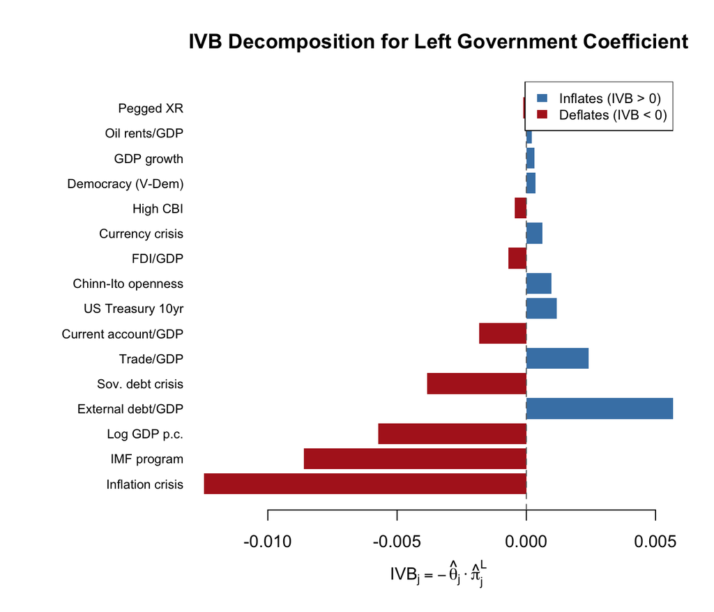

```r
# Sort by absolute IVB
ord <- order(abs(tab_ivb$IVB_L), decreasing = TRUE)
ivb_sorted <- tab_ivb$IVB_L[ord]
labels_sorted <- tab_ivb$Collider[ord]

par(mar = c(5, 10, 4, 2))
cols <- ifelse(ivb_sorted > 0, "steelblue", "firebrick")
barplot(ivb_sorted, names.arg = labels_sorted, horiz = TRUE, las = 1,
        col = cols, border = NA,
        main = "IVB Decomposition for Left Government Coefficient",
        xlab = expression(IVB[j] == -hat(theta)[j] %.% hat(pi)[j]^L),
        cex.names = 0.75)
abline(v = 0, lty = 2, col = "gray40")
legend("topright",
       legend = c("Inflates (IVB > 0)", "Deflates (IVB < 0)"),
       fill = c("steelblue", "firebrick"), border = NA, cex = 0.8)
```

## Total IVB and No-Controls Benchmark

```r
total_ivb_L <- sum(tab_ivb$IVB_L)
beta_long_L <- tab_ivb$beta_long_L[1]

# Model with NO controls (only temporal + FE)
# Use the same sample as the full model for comparability
all_vars <- c("propDom_gt1yr", d_vars, all_controls, temporal_vars, "ccode")
dat_complete <- dat_nooecd[complete.cases(dat_nooecd[, all_vars]), ]

mod_no_controls <- feols(
  propDom_gt1yr ~ l1_rightwing + l1_leftwing +
    time + time2 + time3 | ccode,
  data = dat_complete, vcov = "iid"
)
beta_no_controls_L <- coef(mod_no_controls)["l1_leftwing"]
```

- $\hat\beta_L^{\text{long}}$ (with all controls) = 0.1093
- $\hat\beta_L^{\text{no controls}}$ (only temporal + FE, same sample) = 0.1258
- **Total IVB** (sum across all controls) = -0.022011 (-20.1% of $\hat\beta_L^{\text{long}}$)

**Note:** The total IVB (sum of individual IVBs) does not generally equal $\hat\beta_L^{\text{long}} - \hat\beta_L^{\text{no controls}}$ because the IVB decomposition drops one control at a time, not all simultaneously. The sum provides a useful summary of the total sensitivity to control specification.

## Top Contributors

```r
tab_ranked <- tab_ivb[order(abs(tab_ivb$IVB_L), decreasing = TRUE), ]
tab_top <- data.frame(
  Rank    = 1:nrow(tab_ranked),
  Control = tab_ranked$Collider,
  IVB     = round(tab_ranked$IVB_L, 6),
  Pct     = round(100 * tab_ranked$IVB_L / tab_ranked$beta_long_L, 2),
  theta   = round(tab_ranked$theta, 4),
  pi_L    = round(tab_ranked$pi_L, 4),
  stringsAsFactors = FALSE
)
kable(tab_top, digits = 4, row.names = FALSE,
      caption = "Controls ranked by absolute IVB for Left coefficient",
      col.names = c("Rank", "Control", "IVB",
                     "IVB/$\\hat{\\beta}_L$ (\\%)",
                     "$\\hat\\theta_j$", "$\\hat\\pi_j^L$"))
```

Controls ranked by absolute IVB for Left coefficient

| Rank | Control | IVB | IVB/$\hat{\beta}_L$ (%) | $\hat\theta_j$ | $\hat\pi_j^L$ |
| --- | --- | --- | --- | --- | --- |
| 1 | Inflation crisis | -0.0125 | -11.41 | -0.2235 | -0.0558 |
| 2 | IMF program | -0.0086 | -7.87 | -0.0453 | -0.1899 |
| 3 | Log GDP p.c. | -0.0057 | -5.24 | -0.0473 | -0.1213 |
| 4 | External debt/GDP | 0.0057 | 5.20 | 0.0011 | -4.9492 |
| 5 | Sov. debt crisis | -0.0038 | -3.52 | 0.1022 | 0.0377 |
| 6 | Trade/GDP | 0.0024 | 2.20 | -0.0005 | 4.8298 |
| 7 | Current account/GDP | -0.0018 | -1.66 | 0.0026 | 0.6985 |
| 8 | US Treasury 10yr | 0.0012 | 1.08 | 0.0225 | -0.0526 |
| 9 | Chinn-Ito openness | 0.0010 | 0.88 | 0.0046 | -0.2072 |
| 10 | FDI/GDP | -0.0007 | -0.63 | 0.0014 | 0.4911 |
| 11 | Currency crisis | 0.0006 | 0.58 | -0.0096 | 0.0655 |
| 12 | High CBI | -0.0005 | -0.41 | 0.0113 | 0.0403 |
| 13 | Democracy (V-Dem) | 0.0004 | 0.32 | -0.0118 | 0.0300 |
| 14 | GDP growth | 0.0003 | 0.28 | 0.0019 | -0.1613 |
| 15 | Oil rents/GDP | 0.0002 | 0.20 | -0.0023 | 0.0931 |
| 16 | Pegged XR | -0.0001 | -0.11 | -0.0058 | -0.0213 |

# Literature Support for Collider Status

The IVB formula diagnoses **how much** each control shifts the treatment estimate, but **whether** a control is a collider depends on substantive knowledge: does government partisanship cause the control (treatment $\to$ $Z_j$), and does bond denomination choice also cause or respond to the control ($Y \to Z_j$)?

We review the literature for the controls with the largest IVB magnitudes.

## Partisanship $\to$ Inflation Crisis ($Z_{14}$)

There is strong evidence linking government ideology to inflation outcomes:

- **Hibbs (1977, APSR):** Left governments tolerate higher inflation to achieve lower unemployment, the classic partisan theory of macroeconomic policy.
- **Alesina (1987, QJE):** Rational partisan theory predicts temporary inflation increases after left-wing electoral victories.
- **Broz (2002, IO):** Left governments in developing countries have less anti-inflation credibility, potentially triggering inflation crises.

At the same time, inflation crises directly affect the currency denomination of sovereign bonds (investors demand hard-currency denomination during inflationary episodes), establishing a plausible $Y \to Z$ link.

**Implication:** Inflation crisis is a plausible collider. The very large $\hat\theta_{14}$ (inflation crisis strongly reduces domestic-currency issuance) combined with partisan differences in inflation risk creates IVB.

## Partisanship $\to$ IMF Program ($Z_{12}$)

There is moderate evidence that partisanship affects IMF program participation:

IMF programs may also influence bond denomination through conditionality requiring macroeconomic reforms.

## Partisanship $\to$ GDP per capita ($Z_1$) and Growth ($Z_2$)

- **Alesina, Roubini & Cohen (1997):** Partisan effects on macroeconomic outcomes are well-documented but modest and temporary.
- The 12-month lag substantially mitigates contemporaneous collider concerns for these variables, as partisan effects on GDP levels take time to materialize.

## Partisanship $\to$ Current Account ($Z_4$) and Trade ($Z_5$)

# Summary

```r
# Classify controls by IVB magnitude
top5 <- tab_ivb[order(abs(tab_ivb$IVB_L), decreasing = TRUE), ][1:5, ]

summary_all <- data.frame(
  Control = tab_ivb$Collider,
  `D causes Z?` = c(
    "Weak (lagged 12mo)", "Weak (lagged 12mo)",      # GDP p.c., GDP growth
    "Weak", "Weak",                                    # External debt, Current account
    "Possible", "Weak",                                # Trade, Oil rents
    "Weak", "No (exogenous)",                          # FDI, US Treasury
    "Possible", "Weak",                                # Peg, CBI
    "Possible", "Possible",                            # Chinn-Ito, IMF
    "Weak", "Strong (partisan theory)",                # Currency crisis, Inflation crisis
    "Weak", "Possible"                                 # Sov debt crisis, Democracy
  ),
  `Y causes Z?` = c(
    "Weak", "Weak",                                    # GDP p.c., GDP growth
    "Possible", "Possible",                            # External debt, Current account
    "Weak", "No",                                      # Trade, Oil rents
    "Possible", "No (exogenous)",                      # FDI, US Treasury
    "Possible", "Weak",                                # Peg, CBI
    "Possible", "Possible",                            # Chinn-Ito, IMF
    "Possible", "Strong",                              # Currency crisis, Inflation crisis
    "Possible", "Weak"                                 # Sov debt crisis, Democracy
  ),
  `Collider?` = c(
    "Unlikely", "Unlikely",
    "Unlikely", "Unlikely",
    "Unlikely", "Unlikely",
    "Unlikely", "No",
    "Possible", "Unlikely",
    "Possible", "Possible",
    "Possible", "Plausible",
    "Possible", "Unlikely"
  ),
  IVB = round(tab_ivb$IVB_L, 6),
  `IVB pct` = round(100 * tab_ivb$IVB_L / tab_ivb$beta_long_L, 2),
  check.names = FALSE, stringsAsFactors = FALSE
)

kable(summary_all, digits = 4, row.names = FALSE,
      caption = "Summary: Literature evidence and IVB magnitudes for Left coefficient",
      col.names = c("Control", "$D \\to Z$?", "$Y \\to Z$?",
                     "Collider?", "IVB",
                     "IVB/$\\hat{\\beta}_L$ (\\%)"))
```

Summary: Literature evidence and IVB magnitudes for Left coefficient

| Control | $D \to Z$? | $Y \to Z$? | Collider? | IVB | IVB/$\hat{\beta}_L$ (%) |
| --- | --- | --- | --- | --- | --- |
| Log GDP p.c. | Weak (lagged 12mo) | Weak | Unlikely | -0.0057 | -5.24 |
| GDP growth | Weak (lagged 12mo) | Weak | Unlikely | 0.0003 | 0.28 |
| External debt/GDP | Weak | Possible | Unlikely | 0.0057 | 5.20 |
| Current account/GDP | Weak | Possible | Unlikely | -0.0018 | -1.66 |
| Trade/GDP | Possible | Weak | Unlikely | 0.0024 | 2.20 |
| Oil rents/GDP | Weak | No | Unlikely | 0.0002 | 0.20 |
| FDI/GDP | Weak | Possible | Unlikely | -0.0007 | -0.63 |
| US Treasury 10yr | No (exogenous) | No (exogenous) | No | 0.0012 | 1.08 |
| Pegged XR | Possible | Possible | Possible | -0.0001 | -0.11 |
| High CBI | Weak | Weak | Unlikely | -0.0005 | -0.41 |
| Chinn-Ito openness | Possible | Possible | Possible | 0.0010 | 0.88 |
| IMF program | Possible | Possible | Possible | -0.0086 | -7.87 |
| Currency crisis | Weak | Possible | Possible | 0.0006 | 0.58 |
| Inflation crisis | Strong (partisan theory) | Strong | Plausible | -0.0125 | -11.41 |
| Sov. debt crisis | Weak | Possible | Possible | -0.0038 | -3.52 |
| Democracy (V-Dem) | Possible | Weak | Unlikely | 0.0004 | 0.32 |

## Key Findings

```r
# Identify the top 3 contributors
top3 <- tab_ivb[order(abs(tab_ivb$IVB_L), decreasing = TRUE), ][1:3, ]
cat("Top 3 IVB contributors (by absolute magnitude):\n")
```

```
## Top 3 IVB contributors (by absolute magnitude):
```

```r
for (i in 1:3) {
  cat(sprintf("  %d. %s: IVB = %.6f (%.1f%% of beta_L)\n",
              i, top3$Collider[i], top3$IVB_L[i],
              100 * top3$IVB_L[i] / top3$beta_long_L[i]))
}
```

```
##   1. Inflation crisis: IVB = -0.012471 (-11.4% of beta_L)
##   2. IMF program: IVB = -0.008605 (-7.9% of beta_L)
##   3. Log GDP p.c.: IVB = -0.005735 (-5.2% of beta_L)
```

# References

- Alesina, A. (1987). Macroeconomic Policy in a Two-Party System as a Repeated Game. *Quarterly Journal of Economics*, 102(3), 651–678.
- Alesina, A., Roubini, N., & Cohen, G. D. (1997). *Political Cycles and the Macroeconomy*. MIT Press.
- Ballard-Rosa, C., Mosley, L., & Wellhausen, R. L. (2022). Coming to Terms: The Politics of Sovereign Bond Denomination. *International Organization*, 76(1), 126–153.
- Bearce, D. H. (2003). Societal Preferences, Partisan Agents, and Monetary Policy Outcomes. *International Organization*, 57(2), 373–410.
- Bearce, D. H. & Hallerberg, M. (2011). Democracy and De Facto Exchange Rate Regimes. *Economics & Politics*, 23(2), 172–194.
- Broz, J. L. (2002). Political System Transparency and Monetary Commitment Regimes. *International Organization*, 56(4), 861–887.
- Broz, J. L. & Frieden, J. A. (2001). The Political Economy of International Monetary Relations. *Annual Review of Political Science*, 4, 317–343.
- Dreher, A. (2006). IMF and Economic Growth: The Effects of Programs, Loans, and Compliance with Conditionality. *World Development*, 34(5), 769–788.
- Hibbs, D. A. (1977). Political Parties and Macroeconomic Policy. *American Political Science Review*, 71(4), 1467–1487.
- Milner, H. V. & Judkins, B. (2004). Partisanship, Trade Policy, and Globalization: Is There a Left-Right Divide on Trade Policy? *International Studies Quarterly*, 48(1), 95–119.
- Quinn, D. P. & Toyoda, A. M. (2008). Does Capital Account Liberalization Lead to Growth? *Review of Financial Studies*, 21(3), 1403–1449.
- Vreeland, J. R. (2003). *The IMF and Economic Development*. Cambridge University Press.